# Developing Depression Risk Prediction Models

## Using the National Health and Nutrition Examination Survey Data 2013-2014

Group 2: Bei Wang, Fangyuan Zhao, Kat Hutcheson, Amro Hassan

# 1. Introduction

In the US, it is estimated that almost ten million people suffer from depression, while only one-third of them received appropriate treatment. Social service and health care professionals are well-situated to assess depression risk of their clients or patients during brief encounters. But this has been challenging because people who are at higher risk of mental disorders might be reluctant to respond to standardized questionnaires (e.g. PHQ-2 and PHQ-9) for depression screening. Moreover, there is no efficient and user-friendly predictive tool for this purpose.

Therefore, our *main goal* is to build an efficient depression risk prediction model for social service and healthcare practitioners to use to screen people who might be at risk of depression. Our *second aim* is to examine whether people of different racial/ethnic backgrounds have different predictors.

# 2. Method

We used the National Health and Nutrition Examination Survey (NHANES, 2013-2014) initiated by the Centers for Disease Control and Prevention (CDC) and the National Center for Health Statistics (NCHS). The NHANES aims to provide US national health data on the prevalence of major diseases and associated risk factors among adults and children.

In our present project, we focus on NHANES survey questions that would be easy to ask in brief health care or social service encounters and does not require lengthy and expensive tests. Based on this criteria, we narrowed down to 1166 features in aspects of demographic, socioeconomic, dietary, socio-psychological, behavioral health, medical conditions, functional health, and life experience.

We further selected features and applied several supervised learning techniques to develop a model with the best prediction performance. Our final model contains 20 features. **Please see our documentation for full details of our method.**

# 3. Prepare and explore the data

## 3.1 Merge data

```python
import sklearn
import pandas as pd
import numpy as np
import matplotlib.pyplot as plt
import seaborn as sns
from functools import reduce
import os
from dmba import classificationSummary
import warnings
warnings.filterwarnings('ignore')
#imputation
from sklearn.impute import SimpleImputer
%matplotlib inline
```

```python
os.getcwd()
```

```
'/Users/zhao/Desktop/Data_Mining'
```

```python
#not including medications
os.chdir('/Users/zhao/Desktop/Data_Mining/data')
files= ['demographic.csv', 'diet.csv', 'questionnaire.csv'] #only use demo, diet, and questionnaire
demo= pd.read_csv('demographic.csv')
diet= pd.read_csv('diet.csv')
qr= pd.read_csv('questionnaire.csv')
```

```python
print('demo', demo.shape)
print('diet', diet.shape)
print('ques', qr.shape)
```

```
demo (10175, 47)
diet (9813, 168)
ques (10175, 953)
```

```python
ls=[]
for file in files:
    df= pd.read_csv(file)
    ls.append(df)
df_merge= reduce(lambda x,y: pd.merge(x, y,  how='inner', on= 'SEQN', suffixes=('', '_drop')), ls)
df_merge.drop([col for col in df_merge.columns if 'drop' in col], axis=1, inplace=True)
print("merged df shape:", df_merge.shape)
```

```
merged df shape: (9813, 1166)
```

```python
#check for duplicated SEQN
df_merge.SEQN.duplicated().value_counts()
```

```
False    9813
Name: SEQN, dtype: int64
```

### Get a codebook for the dataset for meaning of features

This was done in a seperate files; some of the variables names are inconsistent, resulting in NaN, so I changed them manually.

```python
cbook= pd.read_csv('nhanes_2013_2014_codebook.csv')
#convert variable names to upper class to match with df_merge
cbook['variable']= cbook['variable'].str.upper()
```

## 3.2 Missingness

```python
#replace all 7s and 9s as null
df_merge.replace({7:None, 9:None, 77:None,99:None,777:None,999:None,7777:None,9999:None,77777:None,99999:None,
            777777:None,999999:None,55:None,555:None,5555:None,8:None,88:None}, inplace=True)
```

### Drop observations with missingness in target feature

```python
#test
df_merge.DPQ050.describe
```

```
<bound method NDFrame.describe of 0       0.0
1       0.0
2       0.0
3       NaN
4       3.0
       ...
9808    0.0
9809    NaN
9810    NaN
9811    NaN
9812    NaN
Name: DPQ050, Length: 9813, dtype: float64>
```

```python
#create phq9 scores and drop rows with any item missing
df_merge['phq9']= df_merge[['DPQ010','DPQ020','DPQ030','DPQ040', 'DPQ050', 'DPQ060', 'DPQ070', 'DPQ080', 'DPQ090']].sum(axis=1, skipna=False)
```

```python
#To prep for visualization, assign categories to the original data and data after remving missing phq9 scores
orig = df_merge #original data set to be used for comparison
orig['DataSet'] = np.where(df_merge['phq9'].notna(), 'Cleaned Data', 'Original Data')  #add column
```

```python
#drop rows with any item missing for phq9

df_merge= df_merge[df_merge['phq9'].notna()]
print(df_merge.shape)
```

```
(5372, 1168)
```

```python
df_merge.phq9.describe()
```

```
count    5372.000000
mean        3.311616
std         4.396482
min         0.000000
25%         0.000000
50%         2.000000
75%         5.000000
max        27.000000
Name: phq9, dtype: float64
```

### Compare the Amount of Records by Ethnicity (pre and post dropping missing values)

```
findfont: Font family ['calibri'] not found. Falling back to DejaVu Sans.
findfont: Font family ['calibri'] not found. Falling back to DejaVu Sans.
```

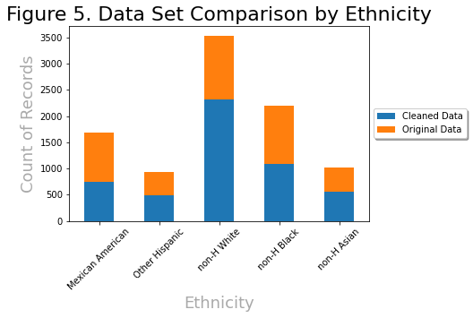

```python
font1 = {'family':'calibri','color':'darkgray','size':18}
font2 = {'family':'calibri','color':'black','size':22}

plt.figure(figsize=(25,25))
ct = pd.crosstab(orig.RIDRETH3, orig.DataSet)

ax = ct.plot(kind='bar', stacked=True, rot= 45)
ax.legend(ncol=1, shadow=True, loc='center left', bbox_to_anchor=(1, 0.5))


plt.xlabel("Ethnicity", fontdict=font1)
plt.ylabel("Count of Records", fontdict = font1)
plt.title("Figure 5. Data Set Comparison by Ethnicity", fontdict = font2)
ax.set_xticklabels(['Mexican American', 'Other Hispanic', 'non-H White', 'non-H Black', 'non-H Asian'])


plt.show()
```

### Drop feature columns with more than 20% missing data

```python
#drop columns with more than no missing data
df_merge= df_merge.dropna(thresh= 0.8*len(df_merge), axis=1)
```

### Drop non-numeric columns

```python
# exclude non-numeric values
df_merge = df_merge.select_dtypes(['number'])
print(len(df_merge.columns), 'columns left')
```

```
291 columns left
```

```python
df_merge.info()
```

```
<class 'pandas.core.frame.DataFrame'>
Int64Index: 5372 entries, 0 to 9808
Columns: 291 entries, SEQN to phq9
dtypes: float64(278), int64(13)
memory usage: 12.0 MB
```

### Impute missing values

```python
imp_mode=SimpleImputer(strategy='most_frequent')
df_merge = pd.DataFrame(imp_mode.fit_transform(df_merge), columns=df_merge.columns)
#could try other imputation method KNN
```

## 3.3 Feature selection (initial selection)

To achieve our goal of building a model with questions that are brief and easy to ask, we went through a manual selection of features. This step includes dropping administration-related features (e.g., language of interview, interpreter code), features that require lengthy dietary assessments, and duplicated questions.

```python
#go over the dictionary manually and drop the unwanted variables
col = df_merge.columns
df_col = cbook[cbook['variable'].isin(col)]
df_col.to_csv(r'df_col.csv') #done in excel
```

```python
#remove variables that are related to administration/operation (e.g. language of interview, interpreter code)
#admin = pd.read_csv('C:/Users/AmroHassan/Google Drive/Classroom/31008 1-Data Mining Principles/Project/Depression-risk-main/Project Data/Depression-risk-main/data/administrative_col.csv')
admin = pd.read_csv('administrative_col.csv')
admin_col = admin.columns
df_merge = df_merge.drop(admin.columns, 1)
```

```python
#remove variables that are collected and calculated after very detailed Dietary Interviews
#(e.g. total dietary fiber)
#Can keep variables that can be easily answered
#(e.g. Total bottled water drank yesterday)
#dietary = pd.read_csv('C:/Users/AmroHassan/Google Drive/Classroom/31008 1-Data Mining Principles/Project/Depression-risk-main/Project Data/Depression-risk-main/data/diet_col.csv')
dietary = pd.read_csv('diet_col.csv')
diet_col = dietary.columns
df_merge = df_merge.drop(dietary.columns, 1)
```

```python
# remove one of HUQ010 and HSD010 (identical question asked in different surveys, highly correlated)
df_merge = df_merge.drop('HUQ010', 1)
```

```python
df_merge.info()
```

```
<class 'pandas.core.frame.DataFrame'>
RangeIndex: 5372 entries, 0 to 5371
Columns: 211 entries, SEQN to phq9
dtypes: float64(211)
memory usage: 8.6 MB
```

```python
df_merge.to_csv(r'df_merge.csv')
```

```python
df_merge.shape
```

```
(5372, 211)
```

Now, after cleaning, only 211 columns left

## 3.4 Target variable (PHQ9) definition and visualization

The PHQ-9 was found to have acceptable diagnostic properties for detecting major depressive disorder for cut-off scores between 8 and 11. We explore this variable in two different ways:

- PHQ9 itself is a numeric feature with a possible range from 0 to 27
- PHQ9 was dichotomized in (>=8/<8) to determine depression
- We also explored more restrict thresholds that have been used conventionally to define depression such as moderate and severe depression.
- We further explored frequencies of suicidal ideation.
- We end up using the ">=8/<8" threshold to define depression in the current project for the other definitions result in too few cases of depression to develop a prediction model.

#### Numeric PHQ9

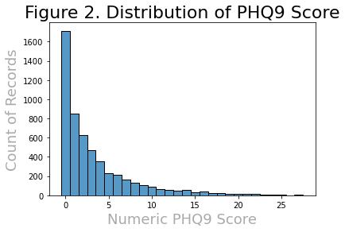

```python
sns.histplot(df_merge.phq9, discrete=True)
plt.xlabel("Numeric PHQ9 Score", fontdict=font1)
plt.ylabel("Count of Records", fontdict = font1)
plt.title("Figure 2. Distribution of PHQ9 Score", fontdict = font2)
```

#### Depression (dichotomized)

```python
df_merge['mild_dep']= np.where(df_merge['phq9']>=8,1,0)
print('mild', df_merge['mild_dep'].value_counts())
```

```
mild 0    4624
1     748
Name: mild_dep, dtype: int64
```

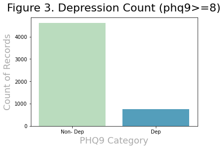

```python
dx = sns.countplot(x='mild_dep', data = df_merge, palette = "GnBu")
dx.set_ylabel("Count of Records", fontdict = font1)
dx.set_xlabel("PHQ9 Category", fontdict=font1)
dx.set_title('Figure 3. Depression Count (phq9>=8)', y=1.03, fontdict=font2)
dx.set_xticklabels(['Non- Dep','Dep'])

plt.show()
```

#### Moderate depression

```python
df_merge['mod_dep']= np.where(df_merge['phq9']>=15,1,0)
print('modereate', df_merge['mod_dep'].value_counts())
```

```
modereate 0    5177
1     195
Name: mod_dep, dtype: int64
```

```
[Text(0, 0, 'Non-Mod Dep'), Text(1, 0, 'Mod Dep')]
```

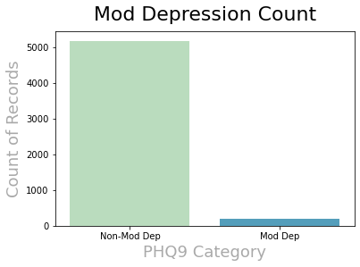

```python
dx = sns.countplot(x='mod_dep', data = df_merge, palette = "GnBu")
dx.set_ylabel("Count of Records", fontdict = font1)
dx.set_xlabel("PHQ9 Category", fontdict=font1)
dx.set_title('Mod Depression Count', y=1.03, fontdict=font2)
dx.set_xticklabels(['Non-Mod Dep','Mod Dep'])
```

#### Severe depression

```python
df_merge['sev_dep']= np.where(df_merge['phq9']>=20,1,0)
print('severe', df_merge['sev_dep'].value_counts())
```

```
severe 0    5315
1      57
Name: sev_dep, dtype: int64
```

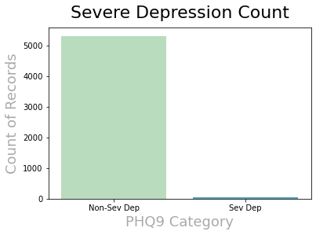

```python
dx = sns.countplot(x='sev_dep', data = df_merge, palette = "GnBu")
dx.set_ylabel("Count of Records", fontdict = font1)
dx.set_xlabel("PHQ9 Category", fontdict=font1)
dx.set_title('Severe Depression Count', y=1.03, fontdict=font2)
dx.set_xticklabels(['Non-Sev Dep','Sev Dep'])

plt.show()
```

#### Suicidal ideation

```python
df_merge['suicidal']= np.where(df_merge['DPQ090']>0,1,0)
print('suicidal', df_merge['suicidal'].value_counts())
```

```
suicidal 0    5189
1     183
Name: suicidal, dtype: int64
```

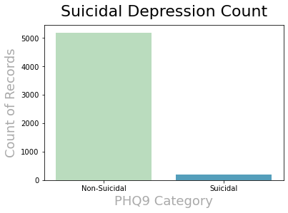

```python
dx = sns.countplot(x='suicidal', data = df_merge, palette = "GnBu")
dx.set_ylabel("Count of Records", fontdict = font1)
dx.set_xlabel("PHQ9 Category", fontdict=font1)
dx.set_title('Suicidal Depression Count', y=1.03, fontdict=font2)
dx.set_xticklabels(['Non-Suicidal','Suicidal'])

plt.show()
```

## 3.4 Other key features exploration

We explored other key demographic features to describe this population.

- A large proportion of the population is non-Hispanic white while there are also Hispanics, non-Hispanic blacks, and non-Hispanic Asians.
- People's age ranges from 18 to 80 with larger proportions of the youngest and the oldest group.
- There are more females than males. This population is also highly educated. About a quarter of the population was not US-born.

### Race and ethnicity

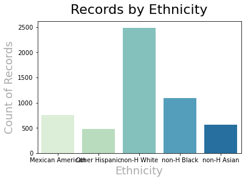

```python
dx = sns.countplot(x='RIDRETH3', data = df_merge, palette = "GnBu")
dx.set_ylabel("Count of Records", fontdict = font1)
dx.set_xlabel("Ethnicity", fontdict=font1)
dx.set_title('Records by Ethnicity', y=1.03, fontdict=font2)
dx.set_xticklabels(['Mexican American', 'Other Hispanic', 'non-H White', 'non-H Black', 'non-H Asian'])

plt.show()
```

### Explore Age, Education, Country of Birth, and Gender

```
findfont: Font family ['calibri'] not found. Falling back to DejaVu Sans.
findfont: Font family ['calibri'] not found. Falling back to DejaVu Sans.
```

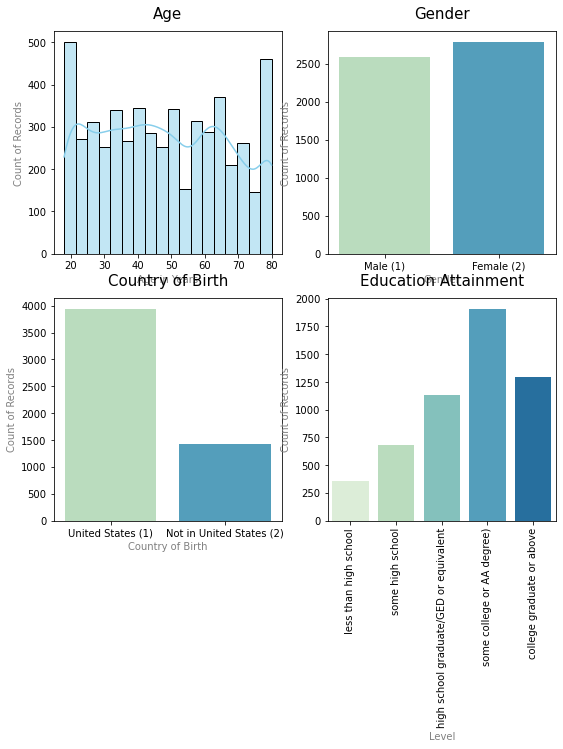

```python
fig, axs = plt.subplots(2, 2, figsize=(9, 9))
font1 = {'family':'calibri','color':'gray','size':10}
font2 = {'family':'calibri','color':'black','size':15}

d1=sns.histplot(data=df_merge, x="RIDAGEYR", kde=True, color="skyblue", ax=axs[0, 0])
d2=sns.countplot(data=df_merge, x="RIAGENDR", palette="GnBu", ax=axs[0, 1])
d3=sns.countplot(data=df_merge, x="DMDBORN4", palette='GnBu', ax=axs[1, 0])
d4=sns.countplot(data=df_merge, x="DMDEDUC2", palette="GnBu", ax=axs[1, 1])

d1.set_ylabel("Count of Records", fontdict = font1)
d1.set_xlabel("Age in Years", fontdict=font1)
d1.set_title('Age', y=1.03, fontdict=font2)


d2.set_ylabel("Count of Records", fontdict = font1)
d2.set_xlabel("Gender", fontdict=font1)
d2.set_title('Gender', y=1.03, fontdict=font2)
d2.set_xticklabels(['Male (1)','Female (2)'])

d3.set_ylabel("Count of Records", fontdict = font1)
d3.set_xlabel("Country of Birth", fontdict=font1)
d3.set_title('Country of Birth', y=1.03, fontdict=font2)
d3.set_xticklabels(['United States (1)','Not in United States (2)'])

d4.set_ylabel("Count of Records", fontdict = font1)
d4.set_xlabel("Level", fontdict=font1)
d4.set_title('Education Attainment', y=1.03, fontdict=font2)
d4.set_xticklabels(['less than high school', 'some high school', 'high school graduate/GED or equivalent',
                    'some college or AA degree)', 'college graduate or above'], rotation = 90)

plt.show()
```

## 3.5 Feature selection (feature importance)

### Create a function for normalizing data

```python
from sklearn.preprocessing import StandardScaler
def normalize_data(X):
    X_std= pd.DataFrame(StandardScaler().fit_transform(X))
    X_std.columns= X.columns
    return X_std
```

```python
from sklearn.metrics import accuracy_score
from matplotlib import pyplot
from sklearn.model_selection import train_test_split
#partition into X and y
target=['mild_dep']
drop_features= ['phq9',
                'SEQN',
                'DPQ010', 'DPQ020', 'DPQ030', 'DPQ040', 'DPQ050', 'DPQ060','DPQ070','DPQ080', 'DPQ090',
               'mild_dep', 'sev_dep', 'suicidal', 'mod_dep']
X = df_merge[df_merge.columns.drop(drop_features)]
y= df_merge[target]
#normalize predictors
X= normalize_data(X)
# training and validation sets split
train_X, valid_X, train_y, valid_y = train_test_split(X, y, test_size=0.4, random_state=42, stratify=y)
print('Training_X: ', train_X.shape)
print('Validation_X: ', valid_X.shape)
print('Training_y: ', train_y.shape)
print('Validation_y: ', valid_y.shape)
```

```
Training_X:  (3223, 200)
Validation_X:  (2149, 200)
Training_y:  (3223, 1)
Validation_y:  (2149, 1)
```

### XGboost for feature selection

We used XGBoost to estimate the importance of features and selected the top 30 features with highest importance. Importance provides a score that indicates how useful or valuable each feature was in the construction of the boosted decision trees within the model. Importance is calculated from each single decision tree by the among that each attribute split improves the performance measure, weighted by the number of observations the node is responsible for. Feature importances were then averaged across all trees in the model.

```python
from xgboost import XGBClassifier
from sklearn.metrics import classification_report, accuracy_score, confusion_matrix
xgboost = XGBClassifier()
xgboost.fit(train_X, train_y)
importance= xgboost.feature_importances_
columns= df_merge.columns
df = pd.DataFrame({'feature': train_X.columns, 'importance': importance})
df = df.sort_values('importance', ascending=False)
```

```
[21:49:59] WARNING: /Users/runner/work/xgboost/xgboost/src/learner.cc:1115: Starting in XGBoost 1.3.0, the default evaluation metric used with the objective 'binary:logistic' was changed from 'error' to 'logloss'. Explicitly set eval_metric if you'd like to restore the old behavior.
```

```python
#select top 30 features
df30= df[:30]
df30.columns=['variable', 'importance']
df30['variable'] = df30['variable'].apply(lambda x: x.upper())
df30 = pd.merge(left=df30, right=cbook, left_on='variable', right_on='variable', how='left')
```

```python
df30
```

|  | variable | importance | label |
| --- | --- | --- | --- |
| 0 | DLQ040 | 0.041304 | Have serious difficulty concentrating ? |
| 1 | PFQ049 | 0.025456 | Limitations keeping you from working |
| 2 | DLQ050 | 0.021353 | Have serious difficulty walking ? |
| 3 | SLQ050 | 0.019148 | Ever told doctor had trouble sleeping? |
| 4 | INQ132 | 0.018595 | Income from state/county cash assistance |
| 5 | MCQ160F | 0.018373 | Ever told you had a stroke |
| 6 | HSD010 | 0.016697 | General health condition |
| 7 | INQ080 | 0.016604 | Income from retirement/survivor pension |
| 8 | SMQ681 | 0.015933 | Smoked tobacco last 5 days? |
| 9 | DLQ010 | 0.014916 | Have serious difficulty hearing? |
| 10 | HUQ041 | 0.014183 | Type place most often go for healthcare |
| 11 | DUQ370 | 0.014137 | Ever use a needle to inject illegal drug |
| 12 | SMDANY | 0.014032 | Used any tobacco product last 5 days? |
| 13 | MCQ300A | 0.013679 | Close relative had heart attack? |
| 14 | MCQ080 | 0.012445 | Doctor ever said you were overweight |
| 15 | DLQ020 | 0.012373 | Have serious difficulty seeing? |
| 16 | WHQ030 | 0.011153 | How do you consider your weight |
| 17 | SMQ872 | 0.011050 | Last 7-d someone smoked in car? |
| 18 | HSQ510 | 0.011046 | SP have stomach or intestinal illness? |
| 19 | RIAGENDR | 0.010827 | Gender |
| 20 | OHQ770 | 0.010209 | Past yr need dental but couldn't get it |
| 21 | HSQ520 | 0.009626 | SP have flu, pneumonia, ear infection? |
| 22 | DIQ010 | 0.009505 | Doctor told you have diabetes |
| 23 | FSD032C | 0.009473 | HH Couldn't afford balanced meals |
| 24 | CBQ596 | 0.009453 | Heard of My Plate |
| 25 | DBQ700 | 0.008985 | How healthy is the diet |
| 26 | DIQ160 | 0.008097 | Ever told you have prediabetes |
| 27 | PFQ054 | 0.008095 | Need special equipment to walk |
| 28 | HUQ090 | 0.007569 | Seen mental health professional/past yr |
| 29 | MCQ220 | 0.007451 | Ever told you had cancer or malignancy |

```python
#confusion matrix
classificationSummary(valid_y, xgboost.predict(valid_X))
```

```
Confusion Matrix (Accuracy 0.8809)

       Prediction
Actual    0    1
     0 1803   47
     1  209   90
```

#### above shows the problem of imbalanced data

## 3.6 Apply SMOTE to the training set

A problem with imbalanced classification is that there are too few examples of the minority class for a model to effectively learn the decision boundary. One way to solve this problem is to oversample the examples in the minority class. SMOTE works by selecting examples that are close in the feature space, drawing a line between the examples in the feature space and drawing a new sample at a point along that line. Specifically, a random example from the minority class is first chosen. Then k of the nearest neighbors for that example are found (typically k=5). A randomly selected neighbor is chosen and a synthetic example is created at a randomly selected point between the two examples in feature space. (https://machinelearningmastery.com/smote-oversampling-for-imbalanced-classification/)

```python
import imblearn
from collections import Counter
from sklearn.datasets import make_classification
print(imblearn.__version__)
```

```
0.8.1
```

```python
#recreate X,y for mild depression
target=['mild_dep']
drop_features= ['phq9',
                'SEQN',
                'DPQ010', 'DPQ020', 'DPQ030', 'DPQ040', 'DPQ050', 'DPQ060','DPQ070','DPQ080', 'DPQ090',
               'mild_dep', 'sev_dep', 'suicidal', 'mod_dep']
X = df_merge[df_merge.columns.drop(drop_features)]
y= df_merge[target]
#normalize predictors
X= normalize_data(X)
# training and validation sets split
train_X, valid_X, train_y, valid_y = train_test_split(X, y, test_size=0.4, random_state=42, stratify=y)
print('Training_X: ', train_X.shape)
print('Validation_X: ', valid_X.shape)
print('Training_y: ', train_y.shape)
print('Validation_y: ', valid_y.shape)
```

```
Training_X:  (3223, 200)
Validation_X:  (2149, 200)
Training_y:  (3223, 1)
Validation_y:  (2149, 1)
```

```python
train_y.value_counts()
```

```
mild_dep
0           2774
1            449
dtype: int64
```

```python
valid_y.value_counts()
```

```
mild_dep
0           1850
1            299
dtype: int64
```

### The combination of SMOTE and under-sampling (trim the majority class) performs bettern than plain under-sampling (https://arxiv.org/abs/1106.1813)

```python
from imblearn.over_sampling import SMOTE
from imblearn.under_sampling import RandomUnderSampler
from imblearn.pipeline import Pipeline
```

```python
#oversample the minority class to have 40% the number of examples of the majority class
over = SMOTE(sampling_strategy=0.4)
#reduce the number of examples in the majority class to have 50% more than the minority class
under = RandomUnderSampler(sampling_strategy=0.5)
steps = [('o', over), ('u', under)]
pipeline = Pipeline(steps=steps)
```

```python
train_X, train_y=pipeline.fit_resample(train_X, train_y)
```

```python
train_y.value_counts()
```

```
mild_dep
0           2218
1           1109
dtype: int64
```

```python
#test set remain the same
valid_y.value_counts()
```

```
mild_dep
0           1850
1            299
dtype: int64
```

### Re-run feature selection using the more balanced data

```python
xgboost.fit(train_X, train_y)
importance= xgboost.feature_importances_
columns= df_merge.columns
df = pd.DataFrame({'feature': train_X.columns, 'importance': importance})
df = df.sort_values('importance', ascending=False)
#select top 20 features
df20= df[:20]
df20.columns=['variable', 'importance']
df20['variable'] = df20['variable'].apply(lambda x: x.upper())
df20 = pd.merge(left=df20, right=cbook, left_on='variable', right_on='variable', how='left')
```

```
[21:50:11] WARNING: /Users/runner/work/xgboost/xgboost/src/learner.cc:1115: Starting in XGBoost 1.3.0, the default evaluation metric used with the objective 'binary:logistic' was changed from 'error' to 'logloss'. Explicitly set eval_metric if you'd like to restore the old behavior.
```

```python
df20
```

|  | variable | importance | label |
| --- | --- | --- | --- |
| 0 | SLQ050 | 0.071146 | Ever told doctor had trouble sleeping? |
| 1 | PFQ049 | 0.054363 | Limitations keeping you from working |
| 2 | DLQ040 | 0.036362 | Have serious difficulty concentrating ? |
| 3 | RIAGENDR | 0.027911 | Gender |
| 4 | HSD010 | 0.024890 | General health condition |
| 5 | DBQ700 | 0.023468 | How healthy is the diet |
| 6 | CBQ550 | 0.022287 | Eat at restaurants w/ waiter |
| 7 | DUQ370 | 0.022260 | Ever use a needle to inject illegal drug |
| 8 | SMQ863 | 0.019702 | Used nicotine replacement last 5 days? |
| 9 | OHQ770 | 0.018244 | Past yr need dental but couldn't get it |
| 10 | MCQ010 | 0.016550 | Ever been told you have asthma |
| 11 | DIQ160 | 0.013236 | Ever told you have prediabetes |
| 12 | MCQ080 | 0.012803 | Doctor ever said you were overweight |
| 13 | INQ080 | 0.010637 | Income from retirement/survivor pension |
| 14 | MCQ160F | 0.010082 | Ever told you had a stroke |
| 15 | HSQ510 | 0.009600 | SP have stomach or intestinal illness? |
| 16 | PAQ665 | 0.009386 | Moderate recreational activities |
| 17 | DIQ050 | 0.009236 | Taking insulin now |
| 18 | MCQ160K | 0.009196 | Ever told you had chronic bronchitis |
| 19 | WHQ040 | 0.008772 | Like to weigh more, less or same |

```python
df20.to_csv(r'df20.csv')
```

### The classification results are improved (more true positive) after balancing data

However, this does not fully solve the problem of having way too fewer minority than majority class in the target variable. One could applied resampling strategies as we did to both training and testing sets to get a better results in this regards. But we decided to remain the testing set "real" to reduced bias from resampling.

```python
classificationSummary(valid_y, xgboost.predict(valid_X))
```

```
Confusion Matrix (Accuracy 0.8809)

       Prediction
Actual    0    1
     0 1775   75
     1  181  118
```

## 3.7 Selected variables and correlation matrix

```python
var_list= df20.variable.tolist()
var_list.append('mild_dep')
print(var_list)
```

```
['SLQ050', 'PFQ049', 'DLQ040', 'RIAGENDR', 'HSD010', 'DBQ700', 'CBQ550', 'DUQ370', 'SMQ863', 'OHQ770', 'MCQ010', 'DIQ160', 'MCQ080', 'INQ080', 'MCQ160F', 'HSQ510', 'PAQ665', 'DIQ050', 'MCQ160K', 'WHQ040', 'mild_dep']
```

```python
#final dfs of balanced training data
train_y= train_y.filter(var_list)
train_X= train_X.filter(var_list)
#final testing set
valid_y= valid_y.filter(var_list)
valid_X= valid_X.filter(var_list)
```

```python
train_y.value_counts()
```

```
mild_dep
0           2218
1           1109
dtype: int64
```

```python
valid_y.value_counts()
```

```
mild_dep
0           1850
1            299
dtype: int64
```

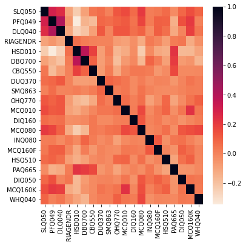

```python
ax=plt.subplots(figsize=(6,6))
corr=train_X.corr()
sns.heatmap(corr, cmap=sns.cm.rocket_r)
```

```python
#get highly correlated pairs, ranked by absolute correlation values
def get_redundant_pairs(df):
    '''Get diagonal and lower triangular pairs of correlation matrix'''
    pairs_to_drop = set()
    cols = df.columns
    for i in range(0, df.shape[1]):
        for j in range(0, i+1):
            pairs_to_drop.add((cols[i], cols[j]))
    return pairs_to_drop

def get_top_abs_correlations(df, n=5):
    au_corr = df.corr().abs().unstack()
    labels_to_drop = get_redundant_pairs(df)
    au_corr = au_corr.drop(labels=labels_to_drop).sort_values(ascending=False)
    return au_corr[0:n]
```

```python
get_top_abs_correlations(train_X, 10)
```

```
PFQ049  DLQ040     0.414039
HSD010  DBQ700     0.375639
PFQ049  HSD010     0.346829
SLQ050  PFQ049     0.299231
DLQ040  HSD010     0.254703
SLQ050  DLQ040     0.249765
        HSD010     0.233957
HSD010  MCQ080     0.232423
MCQ010  MCQ160K    0.232217
HSD010  PAQ665     0.228167
dtype: float64
```

Narrowed down to 20 predictors; some of them are correlated but since we are interested in prediction instead of inference, this level of multicolineraity between variables is acceptable.

```python
train_X.shape
```

```
(3327, 20)
```

# 4. Shortlist promising models

## 4.1 Baseline model: logistic regression

```python
from sklearn.linear_model import LogisticRegression
logit=LogisticRegression()
logit.fit(train_X, train_y)
```

```
LogisticRegression()
```

```python
classificationSummary(train_y, logit.predict(train_X))
```

```
Confusion Matrix (Accuracy 0.7809)

       Prediction
Actual    0    1
     0 1998  220
     1  509  600
```

```python
from sklearn.model_selection import KFold, cross_val_score
from numpy import mean
from numpy import std
#cross-validation
cv = KFold(n_splits=10, random_state=1, shuffle=True)
# evaluate model
scores = cross_val_score(logit, train_X,train_y, scoring='accuracy', cv=cv, n_jobs=-1)
# report performance
print('Accuracy: %.3f (%.3f)' % (mean(scores), std(scores)))
```

```
Accuracy: 0.778 (0.017)
```

```python
coef= logit.coef_
coef= coef.flatten()
columns= train_X.columns
df = pd.DataFrame({'feature': columns,
                   'coefficients': coef})
df = df.sort_values('coefficients', ascending=False)
df.columns=['variable', 'coefficients']
df['variable'] = df['variable'].apply(lambda x: x.upper())
df = pd.merge(left=df, right=cbook, left_on='variable', right_on='variable', how='left')
```

```python
df
```

|  | variable | coefficients | label |
| --- | --- | --- | --- |
| 0 | RIAGENDR | 0.423654 | Gender |
| 1 | HSD010 | 0.351780 | General health condition |
| 2 | DBQ700 | 0.257291 | How healthy is the diet |
| 3 | CBQ550 | 0.200424 | Eat at restaurants w/ waiter |
| 4 | PAQ665 | 0.094339 | Moderate recreational activities |
| 5 | MCQ080 | 0.084951 | Doctor ever said you were overweight |
| 6 | INQ080 | 0.022699 | Income from retirement/survivor pension |
| 7 | MCQ160F | -0.012266 | Ever told you had a stroke |
| 8 | DIQ050 | -0.013438 | Taking insulin now |
| 9 | DIQ160 | -0.017061 | Ever told you have prediabetes |
| 10 | MCQ160K | -0.033257 | Ever told you had chronic bronchitis |
| 11 | DUQ370 | -0.058434 | Ever use a needle to inject illegal drug |
| 12 | SMQ863 | -0.070970 | Used nicotine replacement last 5 days? |
| 13 | HSQ510 | -0.146436 | SP have stomach or intestinal illness? |
| 14 | MCQ010 | -0.163727 | Ever been told you have asthma |
| 15 | OHQ770 | -0.204432 | Past yr need dental but couldn't get it |
| 16 | WHQ040 | -0.277522 | Like to weigh more, less or same |
| 17 | PFQ049 | -0.302586 | Limitations keeping you from working |
| 18 | DLQ040 | -0.333863 | Have serious difficulty concentrating ? |
| 19 | SLQ050 | -0.407296 | Ever told doctor had trouble sleeping? |

```python
import statsmodels.api as sm
logitsm= sm.Logit(train_y, train_X).fit()
logitsm.summary()
```

```
Optimization terminated successfully.
         Current function value: 0.578656
         Iterations 6
```

Logit Regression Results

| Dep. Variable: | mild_dep | No. Observations: | 3327 |
| --- | --- | --- | --- |
| Model: | Logit | Df Residuals: | 3307 |
| Method: | MLE | Df Model: | 19 |
| Date: | Sun, 05 Dec 2021 | Pseudo R-squ.: | 0.09090 |
| Time: | 21:50:34 | Log-Likelihood: | -1925.2 |
| converged: | True | LL-Null: | -2117.7 |
| Covariance Type: | nonrobust | LLR p-value: | 5.772e-70 |

|  | coef | std err | z | P>\|z\| | [0.025 | 0.975] |
| --- | --- | --- | --- | --- | --- | --- |
| SLQ050 | -0.2642 | 0.041 | -6.402 | 0.000 | -0.345 | -0.183 |
| PFQ049 | -0.2760 | 0.046 | -6.065 | 0.000 | -0.365 | -0.187 |
| DLQ040 | -0.3556 | 0.048 | -7.380 | 0.000 | -0.450 | -0.261 |
| RIAGENDR | 0.2526 | 0.040 | 6.247 | 0.000 | 0.173 | 0.332 |
| HSD010 | 0.2457 | 0.046 | 5.286 | 0.000 | 0.155 | 0.337 |
| DBQ700 | 0.1575 | 0.044 | 3.583 | 0.000 | 0.071 | 0.244 |
| CBQ550 | 0.1390 | 0.041 | 3.371 | 0.001 | 0.058 | 0.220 |
| DUQ370 | -0.0618 | 0.043 | -1.431 | 0.153 | -0.147 | 0.023 |
| SMQ863 | -0.0392 | 0.034 | -1.139 | 0.255 | -0.107 | 0.028 |
| OHQ770 | -0.1614 | 0.041 | -3.961 | 0.000 | -0.241 | -0.082 |
| MCQ010 | -0.1255 | 0.041 | -3.054 | 0.002 | -0.206 | -0.045 |
| DIQ160 | -0.0416 | 0.043 | -0.976 | 0.329 | -0.125 | 0.042 |
| MCQ080 | 0.0850 | 0.042 | 2.002 | 0.045 | 0.002 | 0.168 |
| INQ080 | 0.0283 | 0.041 | 0.699 | 0.485 | -0.051 | 0.108 |
| MCQ160F | -0.0172 | 0.043 | -0.402 | 0.688 | -0.101 | 0.067 |
| HSQ510 | -0.1207 | 0.041 | -2.967 | 0.003 | -0.200 | -0.041 |
| PAQ665 | 0.0632 | 0.041 | 1.527 | 0.127 | -0.018 | 0.144 |
| DIQ050 | -0.0268 | 0.042 | -0.644 | 0.519 | -0.108 | 0.055 |
| MCQ160K | -0.0973 | 0.047 | -2.066 | 0.039 | -0.190 | -0.005 |
| WHQ040 | -0.1877 | 0.041 | -4.542 | 0.000 | -0.269 | -0.107 |

### ROC curve

```python
from sklearn.svm import SVC
from sklearn.metrics import roc_curve
from sklearn.metrics import auc
import matplotlib.pyplot as plt
import numpy as np
from sklearn.metrics import RocCurveDisplay
from scipy import interp
```

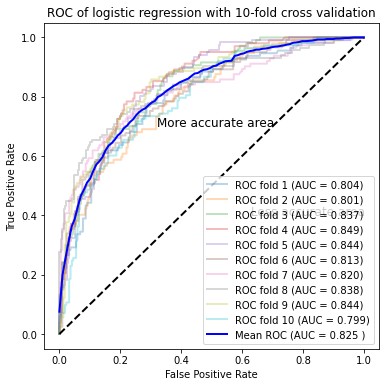

```python
fig2 = plt.figure(figsize=[6,6])
clf= logit
tprs = []
aucs = []
mean_fpr = np.linspace(0,1,100)
i = 1
for train,test in cv.split(train_X,train_y):
    prediction = clf.fit(train_X.iloc[train],train_y.iloc[train]).predict_proba(train_X.iloc[test])
    fpr, tpr, t = roc_curve(train_y.iloc[test], prediction[:, 1])
    tprs.append(interp(mean_fpr, fpr, tpr))
    roc_auc = auc(fpr, tpr)
    aucs.append(roc_auc)
    plt.plot(fpr, tpr, lw=2, alpha=0.3, label='ROC fold %d (AUC = %0.3f)' % (i, roc_auc))
    i= i+1

plt.plot([0,1],[0,1],linestyle = '--',lw = 2,color = 'black')
mean_tpr = np.mean(tprs, axis=0)
mean_auc = auc(mean_fpr, mean_tpr)
plt.plot(mean_fpr, mean_tpr, color='blue',
         label=r'Mean ROC (AUC = %0.3f )' % (mean_auc),lw=2, alpha=1)

plt.xlabel('False Positive Rate')
plt.ylabel('True Positive Rate')
plt.title('ROC of logistic regression with 10-fold cross validation')
plt.legend(loc="lower right")
plt.text(0.32,0.7,'More accurate area',fontsize = 12)
plt.text(0.63,0.4,'Less accurate area',fontsize = 12)
plt.show()
```

## 4.2 Baseline model: Decision tree classifier

```python
from sklearn.tree import DecisionTreeClassifier
from sklearn.model_selection import train_test_split,cross_val_score,GridSearchCV,RandomizedSearchCV

param_grid = {
    'criterion': ['gini', 'entropy'],
    'splitter': ['best', 'random'],
    'max_depth': list(range(2,10)),
    'min_samples_split': list(range(2,6))
}

gridSearch = GridSearchCV(DecisionTreeClassifier(random_state=42), param_grid, cv=5,
                          n_jobs=-1)
gridSearch.fit(train_X, train_y)
print('initial score: ', gridSearch.best_score_)
print('parameters: ', gridSearch.best_params_)

dtree = gridSearch.best_estimator_
```

```
initial score:  0.8491760933866196
parameters:  {'criterion': 'entropy', 'max_depth': 9, 'min_samples_split': 4, 'splitter': 'best'}
```

```python
#cross-validation using training set
cv = KFold(n_splits=10, random_state=1, shuffle=True)
# evaluate model
scores = cross_val_score(dtree, train_X,train_y, scoring='accuracy', cv=cv, n_jobs=-1)
# report performance
print('Accuracy: %.3f (%.3f)' % (mean(scores), std(scores)))
```

```
Accuracy: 0.857 (0.017)
```

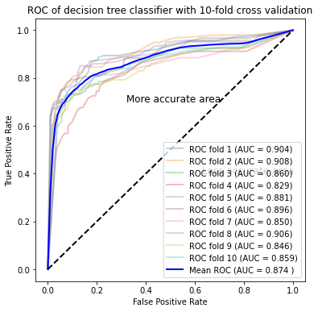

```python
fig2 = plt.figure(figsize=[6,6])
clf= dtree
tprs = []
aucs = []
mean_fpr = np.linspace(0,1,100)
i = 1
for train,test in cv.split(train_X,train_y):
    prediction = clf.fit(train_X.iloc[train],train_y.iloc[train]).predict_proba(train_X.iloc[test])
    fpr, tpr, t = roc_curve(train_y.iloc[test], prediction[:, 1])
    tprs.append(interp(mean_fpr, fpr, tpr))
    roc_auc = auc(fpr, tpr)
    aucs.append(roc_auc)
    plt.plot(fpr, tpr, lw=2, alpha=0.3, label='ROC fold %d (AUC = %0.3f)' % (i, roc_auc))
    i= i+1

plt.plot([0,1],[0,1],linestyle = '--',lw = 2,color = 'black')
mean_tpr = np.mean(tprs, axis=0)
mean_auc = auc(mean_fpr, mean_tpr)
plt.plot(mean_fpr, mean_tpr, color='blue',
         label=r'Mean ROC (AUC = %0.3f )' % (mean_auc),lw=2, alpha=1)

plt.xlabel('False Positive Rate')
plt.ylabel('True Positive Rate')
plt.title('ROC of decision tree classifier with 10-fold cross validation')
plt.legend(loc="lower right")
plt.text(0.32,0.7,'More accurate area',fontsize = 12)
plt.text(0.63,0.4,'Less accurate area',fontsize = 12)
plt.show()
```

## 4.3 Tree-based ensemble classification models: Random Forest

```python
from sklearn.ensemble import RandomForestClassifier
from sklearn.model_selection import train_test_split,cross_val_score,GridSearchCV,RandomizedSearchCV

param_grid = {
    'max_leaf_nodes': list(range(2, 100)),
    'min_samples_split': [3,4,5,7]
}
gridSearch = GridSearchCV(RandomForestClassifier(random_state=42), param_grid, cv=5,
                          n_jobs=-1)
gridSearch.fit(train_X, train_y)
print('initial score: ', gridSearch.best_score_)
print('parameters: ', gridSearch.best_params_)

rf = gridSearch.best_estimator_
```

```
initial score:  0.8708166813429971
parameters:  {'max_leaf_nodes': 98, 'min_samples_split': 5}
```

```python
#cross-validation using training set
cv = KFold(n_splits=10, random_state=1, shuffle=True)
# evaluate model
scores = cross_val_score(rf, train_X,train_y, scoring='accuracy', cv=cv, n_jobs=-1)
# report performance
print('Accuracy: %.3f (%.3f)' % (mean(scores), std(scores)))
```

```
Accuracy: 0.885 (0.009)
```

### ROC curve

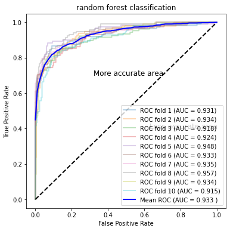

```python
fig2 = plt.figure(figsize=[6,6])
clf= rf
tprs = []
aucs = []
mean_fpr = np.linspace(0,1,100)
i = 1
for train,test in cv.split(train_X,train_y):
    prediction = clf.fit(train_X.iloc[train],train_y.iloc[train]).predict_proba(train_X.iloc[test])
    fpr, tpr, t = roc_curve(train_y.iloc[test], prediction[:, 1])
    tprs.append(interp(mean_fpr, fpr, tpr))
    roc_auc = auc(fpr, tpr)
    aucs.append(roc_auc)
    plt.plot(fpr, tpr, lw=2, alpha=0.3, label='ROC fold %d (AUC = %0.3f)' % (i, roc_auc))
    i= i+1

plt.plot([0,1],[0,1],linestyle = '--',lw = 2,color = 'black')
mean_tpr = np.mean(tprs, axis=0)
mean_auc = auc(mean_fpr, mean_tpr)
plt.plot(mean_fpr, mean_tpr, color='blue',
         label=r'Mean ROC (AUC = %0.3f )' % (mean_auc),lw=2, alpha=1)

plt.xlabel('False Positive Rate')
plt.ylabel('True Positive Rate')
plt.title('random forest classification')
plt.legend(loc="lower right")
plt.text(0.32,0.7,'More accurate area',fontsize = 12)
plt.text(0.63,0.4,'Less accurate area',fontsize = 12)
plt.show()
```

## 4.4 Tree-based ensemble classification models: AdaBoost

```python
from sklearn.ensemble import AdaBoostClassifier

param_grid = {
    'n_estimators': [40, 50, 60],
    'learning_rate': [1, 1.2, 1.5, 1.9]
}
gridSearch = GridSearchCV(AdaBoostClassifier(random_state=42), param_grid, cv=5,
                          n_jobs=-1)
gridSearch.fit(train_X, train_y)
print('initial score: ', gridSearch.best_score_)
print('parameters: ', gridSearch.best_params_)

ada = gridSearch.best_estimator_
```

```
initial score:  0.8747381968434599
parameters:  {'learning_rate': 1.5, 'n_estimators': 60}
```

```python
#cross-validation using training set
cv = KFold(n_splits=10, random_state=1, shuffle=True)
# evaluate model
scores = cross_val_score(ada, train_X,train_y, scoring='accuracy', cv=cv, n_jobs=-1)
# report performance
print('Accuracy: %.3f (%.3f)' % (mean(scores), std(scores)))
```

```
Accuracy: 0.889 (0.012)
```

### ROC curve

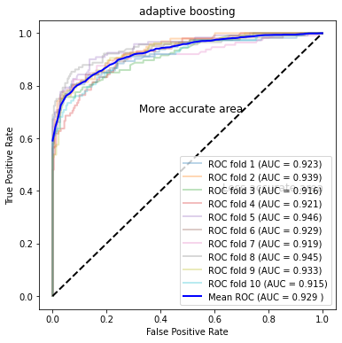

```python
fig3 = plt.figure(figsize=[6,6])
clf= ada
tprs = []
aucs = []
mean_fpr = np.linspace(0,1,100)
i = 1
for train,test in cv.split(train_X,train_y):
    prediction = clf.fit(train_X.iloc[train],train_y.iloc[train]).predict_proba(train_X.iloc[test])
    fpr, tpr, t = roc_curve(train_y.iloc[test], prediction[:, 1])
    tprs.append(interp(mean_fpr, fpr, tpr))
    roc_auc = auc(fpr, tpr)
    aucs.append(roc_auc)
    plt.plot(fpr, tpr, lw=2, alpha=0.3, label='ROC fold %d (AUC = %0.3f)' % (i, roc_auc))
    i= i+1

plt.plot([0,1],[0,1],linestyle = '--',lw = 2,color = 'black')
mean_tpr = np.mean(tprs, axis=0)
mean_auc = auc(mean_fpr, mean_tpr)
plt.plot(mean_fpr, mean_tpr, color='blue',
         label=r'Mean ROC (AUC = %0.3f )' % (mean_auc),lw=2, alpha=1)

plt.xlabel('False Positive Rate')
plt.ylabel('True Positive Rate')
plt.title('adaptive boosting')
plt.legend(loc="lower right")
plt.text(0.32,0.7,'More accurate area',fontsize = 12)
plt.text(0.63,0.4,'Less accurate area',fontsize = 12)
plt.show()
```

## 4.5 Tree-based ensemble classification models: Gradient Boosting

```python
from sklearn.ensemble import GradientBoostingClassifier

param_grid = {
    'n_estimators': [60, 70, 80],
    'max_depth': [ 7,8,9],
    'min_impurity_decrease': [0.1, 0.2, 0.3]
}
gridSearch = GridSearchCV(GradientBoostingClassifier(random_state=42), param_grid, cv=5,
                          n_jobs=-1)
gridSearch.fit(train_X, train_y)
print('initial score: ', gridSearch.best_score_)
print('parameters: ', gridSearch.best_params_)

gradient = gridSearch.best_estimator_
```

```
initial score:  0.8726202894623947
parameters:  {'max_depth': 7, 'min_impurity_decrease': 0.1, 'n_estimators': 60}
```

```python
#cross-validation using training set
cv = KFold(n_splits=10, random_state=1, shuffle=True)
# evaluate model
scores = cross_val_score(gradient, train_X,train_y, scoring='accuracy', cv=cv, n_jobs=-1)
# report performance
print('Accuracy: %.3f (%.3f)' % (mean(scores), std(scores)))
```

```
Accuracy: 0.887 (0.011)
```

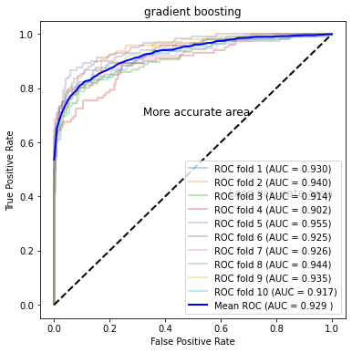

```python
fig4 = plt.figure(figsize=[6,6])
clf= gradient
tprs = []
aucs = []
mean_fpr = np.linspace(0,1,100)
i = 1
for train,test in cv.split(train_X,train_y):
    prediction = clf.fit(train_X.iloc[train],train_y.iloc[train]).predict_proba(train_X.iloc[test])
    fpr, tpr, t = roc_curve(train_y.iloc[test], prediction[:, 1])
    tprs.append(interp(mean_fpr, fpr, tpr))
    roc_auc = auc(fpr, tpr)
    aucs.append(roc_auc)
    plt.plot(fpr, tpr, lw=2, alpha=0.3, label='ROC fold %d (AUC = %0.3f)' % (i, roc_auc))
    i= i+1

plt.plot([0,1],[0,1],linestyle = '--',lw = 2,color = 'black')
mean_tpr = np.mean(tprs, axis=0)
mean_auc = auc(mean_fpr, mean_tpr)
plt.plot(mean_fpr, mean_tpr, color='blue',
         label=r'Mean ROC (AUC = %0.3f )' % (mean_auc),lw=2, alpha=1)

plt.xlabel('False Positive Rate')
plt.ylabel('True Positive Rate')
plt.title('gradient boosting')
plt.legend(loc="lower right")
plt.text(0.32,0.7,'More accurate area',fontsize = 12)
plt.text(0.63,0.4,'Less accurate area',fontsize = 12)
plt.show()
```

## 4.6 Tree-based ensemble classification models: XGBoost

```python
param_grid = {
    'n_estimators': [60, 70, 80],
    'max_depth': [ 7,8,9],
    'min_impurity_decrease': [0.1, 0.2, 0.3]
}
gridSearch = GridSearchCV(XGBClassifier(random_state=42), param_grid, cv=5,
                          n_jobs=-1)
gridSearch.fit(train_X, train_y)
print('initial score: ', gridSearch.best_score_)
print('parameters: ', gridSearch.best_params_)

xgboost = gridSearch.best_estimator_
```

```
[22:00:54] WARNING: /Users/runner/work/xgboost/xgboost/src/learner.cc:576:
Parameters: { "min_impurity_decrease" } might not be used.

  This could be a false alarm, with some parameters getting used by language bindings but
  then being mistakenly passed down to XGBoost core, or some parameter actually being used
  but getting flagged wrongly here. Please open an issue if you find any such cases.


[22:00:54] WARNING: /Users/runner/work/xgboost/xgboost/src/learner.cc:1115: Starting in XGBoost 1.3.0, the default evaluation metric used with the objective 'binary:logistic' was changed from 'error' to 'logloss'. Explicitly set eval_metric if you'd like to restore the old behavior.
initial score:  0.8636094741357899
parameters:  {'max_depth': 7, 'min_impurity_decrease': 0.1, 'n_estimators': 80}
```

```python
#cross-validation using training set
cv = KFold(n_splits=10, random_state=1, shuffle=True)
# evaluate model
scores = cross_val_score(xgboost, train_X,train_y, scoring='accuracy', cv=cv, n_jobs=-1)
# report performance
print('Accuracy: %.3f (%.3f)' % (mean(scores), std(scores)))
```

```
Accuracy: 0.883 (0.014)
```

[output not shown]

[output cut: 35 more lines]

[output not shown]

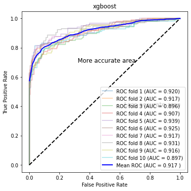

```python
fig5 = plt.figure(figsize=[6,6])
clf= xgboost
tprs = []
aucs = []
mean_fpr = np.linspace(0,1,100)
i = 1
for train,test in cv.split(train_X,train_y):
    prediction = clf.fit(train_X.iloc[train],train_y.iloc[train]).predict_proba(train_X.iloc[test])
    fpr, tpr, t = roc_curve(train_y.iloc[test], prediction[:, 1])
    tprs.append(interp(mean_fpr, fpr, tpr))
    roc_auc = auc(fpr, tpr)
    aucs.append(roc_auc)
    plt.plot(fpr, tpr, lw=2, alpha=0.3, label='ROC fold %d (AUC = %0.3f)' % (i, roc_auc))
    i= i+1

plt.plot([0,1],[0,1],linestyle = '--',lw = 2,color = 'black')
mean_tpr = np.mean(tprs, axis=0)
mean_auc = auc(mean_fpr, mean_tpr)
plt.plot(mean_fpr, mean_tpr, color='blue',
         label=r'Mean ROC (AUC = %0.3f )' % (mean_auc),lw=2, alpha=1)

plt.xlabel('False Positive Rate')
plt.ylabel('True Positive Rate')
plt.title('xgboost')
plt.legend(loc="lower right")
plt.text(0.32,0.7,'More accurate area',fontsize = 12)
plt.text(0.63,0.4,'Less accurate area',fontsize = 12)
plt.show()
```

# 5. Evaluate the best model in the testing set

## 5.1 Test it in the held-out test set

```python
valid_y.value_counts()
```

```
mild_dep
0           1850
1            299
dtype: int64
```

```python
valid_X.shape
```

```
(2149, 20)
```

We decide to use the Random Forest model as the final model because it has the highest AUC, which is our major consideration of model performance. It also has a pretty high accuracy score, very close to the highest ones achieved by AdaBoost and Gradient Boosting.

```python
#retrain the selected model with full training set
rf= sklearn.base.clone(rf)
rf.fit(train_X, train_y)
#test in the hold-out test set
classificationSummary(valid_y, rf.predict(valid_X))
```

```
Confusion Matrix (Accuracy 0.8818)

       Prediction
Actual    0    1
     0 1769   81
     1  173  126
```

```python
from sklearn import metrics
y_pred_proba = rf.predict_proba(valid_X)[::,1]

#calculate AUC of model
auc = metrics.roc_auc_score(valid_y, y_pred_proba)

#print AUC score
print(auc)
```

```
0.8211289885202928
```

```
<sklearn.metrics._plot.roc_curve.RocCurveDisplay at 0x7fba004ce520>
```

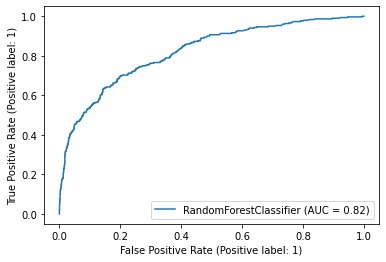

```python
from sklearn.metrics import plot_roc_curve

plot_roc_curve(rf, valid_X, valid_y)
```

For model performance, we are more interested in AUC than accuracy scores because of our imbalanced data as well as our research aim, where we care about the sensitivity and specificity of our model. Our final best model has an AUC of 0.82. In general, 0.7 to 0.8 is considered acceptable, 0.8 to 0.9 is considered excellent, and more than 0.9 is considered outstanding.

## 5.2 Final visualization

```python
def plot_feature_importance(importance,names,model_type):
    #Create arrays from feature importance and feature names
    feature_importance = np.array(importance)
    feature_names = np.array(names)
    #Create a DataFrame using a Dictionary
    data={'feature_names':feature_names,'feature_importance':feature_importance}
    fi_df = pd.DataFrame(data)
    #Sort the DataFrame in order decreasing feature importance
    fi_df.sort_values(by=['feature_importance'], ascending=False,inplace=True)
    #Define size of bar plot
    plt.figure(figsize=(10,8))
    #Plot Searborn bar chart
    sns.barplot(x=fi_df['feature_importance'], y=fi_df['feature_names'])
    #Add chart labels
    plt.title(model_type + 'FEATURE IMPORTANCE')
    plt.xlabel('FEATURE IMPORTANCE')
    plt.ylabel('FEATURE NAMES')
```

```python
#add codebook names
importance= rf.feature_importances_
columns= train_X.columns
df = pd.DataFrame({'feature': columns,
                   'importance': importance})
df = df.sort_values('importance', ascending=False)
df.columns=['variable', 'importance']
df['variable'] = df['variable'].apply(lambda x: x.upper())
df = pd.merge(left=df, right=cbook, left_on='variable', right_on='variable', how='left')
```

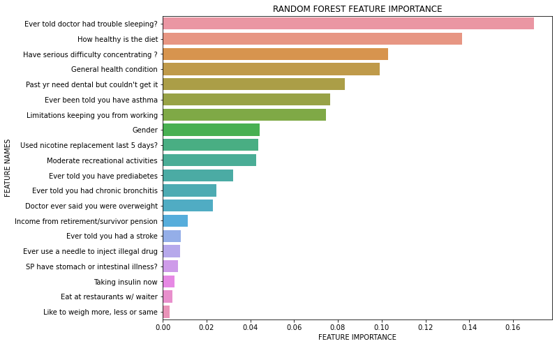

```python
plot_feature_importance(rf.feature_importances_,df.label,'RANDOM FOREST ')
```